# PPG Paint Colors: Final Project EDA

Sai Vivek Chava

2023-12-10

```r
library(tidyverse, tidymodels)
df <- readr::read_csv("paint_project_train_data.csv", col_names = TRUE, show_col_types = F)
df %>% glimpse()
```

```
## Rows: 835
## Columns: 8
## $ R          <dbl> 172, 26, 172, 28, 170, 175, 90, 194, 171, 122, 0, 88, 144, …
## $ G          <dbl> 58, 88, 94, 87, 66, 89, 78, 106, 68, 151, 121, 140, 82, 163…
## $ B          <dbl> 62, 151, 58, 152, 58, 65, 136, 53, 107, 59, 88, 58, 132, 50…
## $ Lightness  <chr> "dark", "dark", "dark", "dark", "dark", "dark", "dark", "da…
## $ Saturation <chr> "bright", "bright", "bright", "bright", "bright", "bright",…
## $ Hue        <dbl> 4, 31, 8, 32, 5, 6, 34, 10, 1, 21, 24, 22, 36, 16, 26, 12, …
## $ response   <dbl> 12, 10, 16, 10, 11, 16, 10, 19, 14, 25, 14, 19, 14, 38, 15,…
## $ outcome    <dbl> 1, 1, 1, 0, 0, 0, 0, 0, 0, 0, 0, 0, 0, 0, 0, 0, 0, 0, 1, 1,…
```

```r
dfii <- df %>%
  mutate(y = boot::logit( (response - 0) / (100 - 0) ) ) %>%
  select(R, G, B,
         Lightness, Saturation, Hue,
         y, outcome)

dfii %>% glimpse()
```

```
## Rows: 835
## Columns: 8
## $ R          <dbl> 172, 26, 172, 28, 170, 175, 90, 194, 171, 122, 0, 88, 144, …
## $ G          <dbl> 58, 88, 94, 87, 66, 89, 78, 106, 68, 151, 121, 140, 82, 163…
## $ B          <dbl> 62, 151, 58, 152, 58, 65, 136, 53, 107, 59, 88, 58, 132, 50…
## $ Lightness  <chr> "dark", "dark", "dark", "dark", "dark", "dark", "dark", "da…
## $ Saturation <chr> "bright", "bright", "bright", "bright", "bright", "bright",…
## $ Hue        <dbl> 4, 31, 8, 32, 5, 6, 34, 10, 1, 21, 24, 22, 36, 16, 26, 12, …
## $ y          <dbl> -1.9924302, -2.1972246, -1.6582281, -2.1972246, -2.0907411,…
## $ outcome    <dbl> 1, 1, 1, 0, 0, 0, 0, 0, 0, 0, 0, 0, 0, 0, 0, 0, 0, 0, 1, 1,…
```

# Exploration

#### Visualizing Null values in the dataframe

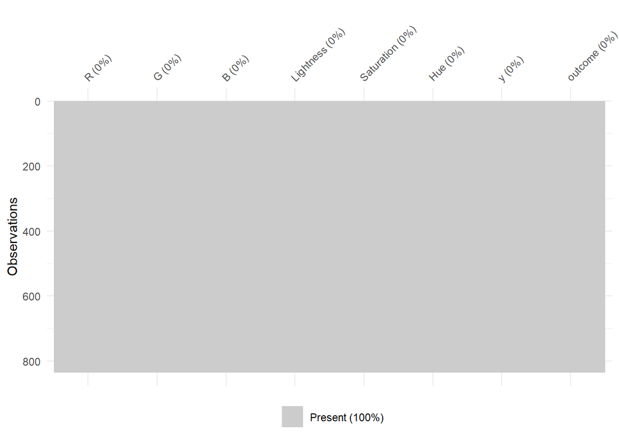

```r
visdat::vis_miss(dfii)
```

#### Visualizing the data types

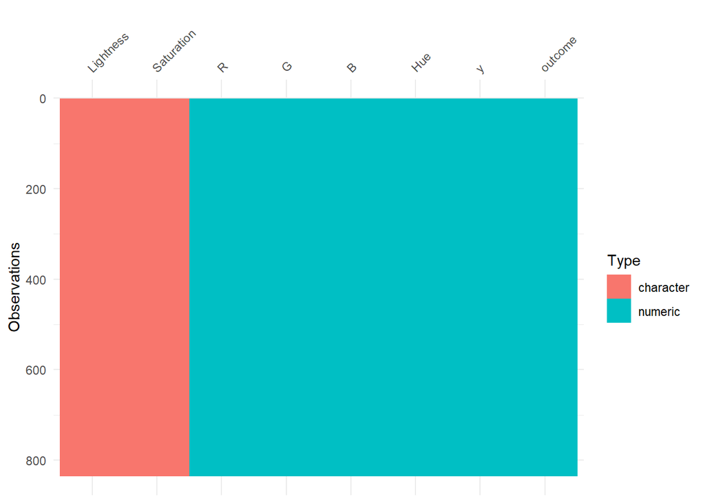

```r
visdat::vis_dat(dfii)
```

#### Minimum and Maximum values in the tibble

```r
cat("Minimum R:", min(dfii$R), " | Minimum G:", min(dfii$G), " | Minimum B:", min(dfii$B), "\n")
```

```
## Minimum R: 0  | Minimum G: 58  | Minimum B: 47
```

```r
cat("Maximum R:", max(dfii$R), " | Maximum G:", max(dfii$G), " | Maximum B:", max(dfii$B))
```

```
## Maximum R: 255  | Maximum G: 241  | Maximum B: 238
```

#### Histogram of the response variable to see the distribution

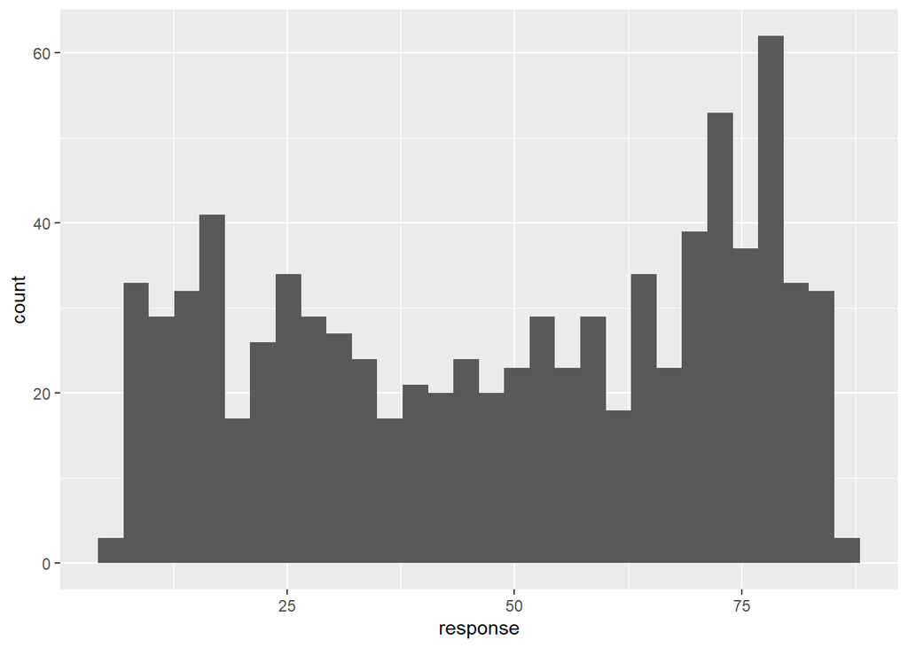

```r
df %>% ggplot(mapping = aes(x=response)) +geom_histogram(bins=30)
```

The histogram of the response variable is not normally distributed.

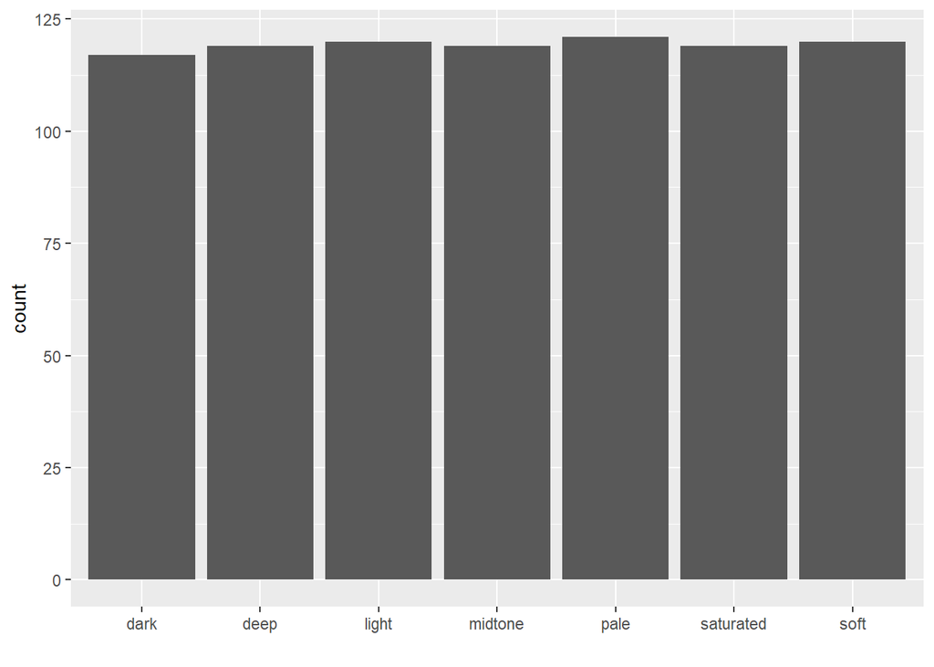

```r
df %>% ggplot(aes(Lightness)) + geom_bar() +xlab('')
```

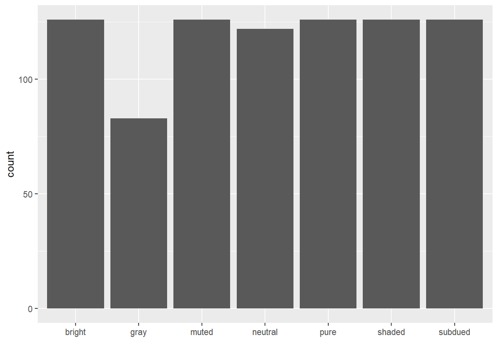

```r
df %>% ggplot(aes(Saturation)) + geom_bar() +xlab('')
```

The distribution of the levels in the saturation is allright.

#### Converting the data to longformat

```r
lf <- dfii %>%
  tibble::rowid_to_column() %>%
  pivot_longer(c(R, G, B, Hue, y))
lf %>% glimpse()
```

```
## Rows: 4,175
## Columns: 6
## $ rowid      <int> 1, 1, 1, 1, 1, 2, 2, 2, 2, 2, 3, 3, 3, 3, 3, 4, 4, 4, 4, 4,…
## $ Lightness  <chr> "dark", "dark", "dark", "dark", "dark", "dark", "dark", "da…
## $ Saturation <chr> "bright", "bright", "bright", "bright", "bright", "bright",…
## $ outcome    <dbl> 1, 1, 1, 1, 1, 1, 1, 1, 1, 1, 1, 1, 1, 1, 1, 0, 0, 0, 0, 0,…
## $ name       <chr> "R", "G", "B", "Hue", "y", "R", "G", "B", "Hue", "y", "R", …
## $ value      <dbl> 172.000000, 58.000000, 62.000000, 4.000000, -1.992430, 26.0…
```

#### Histogram of the numerical columns with corresponding to the outcome

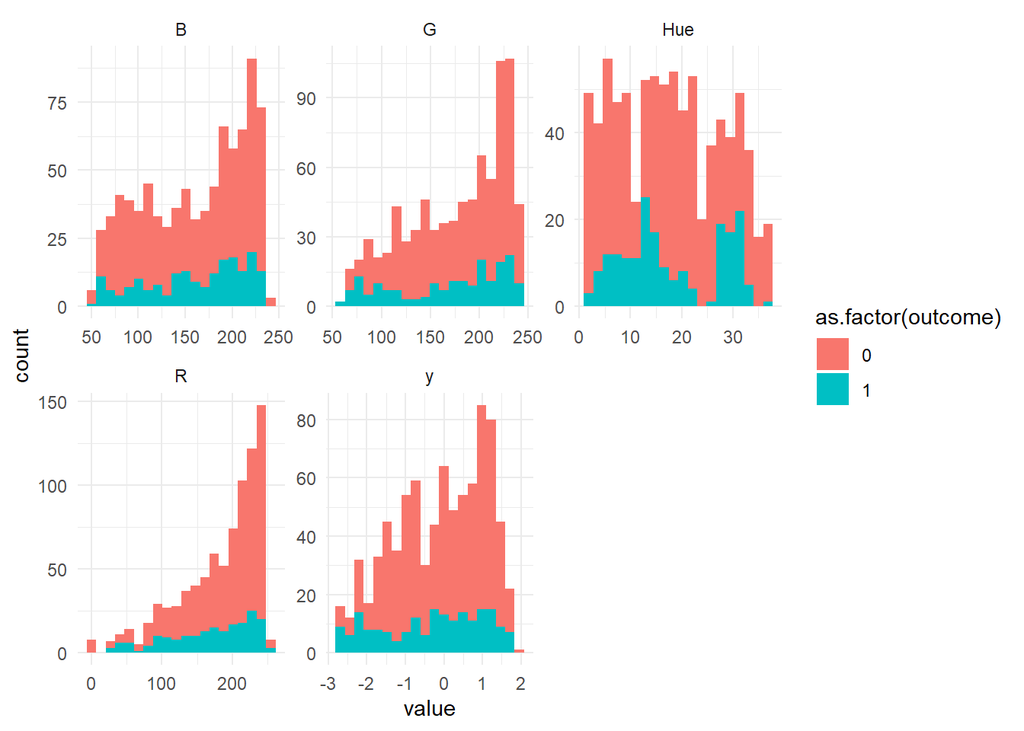

```r
lf %>% ggplot(mapping= aes(x = value, fill=as.factor(outcome))) +geom_histogram(bins = 20) + facet_wrap(~name, scales = 'free') +
  theme_minimal()
```

The distributions seems to be almost similar and heavily skewed towards right for the RGB model. The distribution of event and non-events are also heavily imbalanced.

#### Scatter plot of the numerical columns with respect to outcome

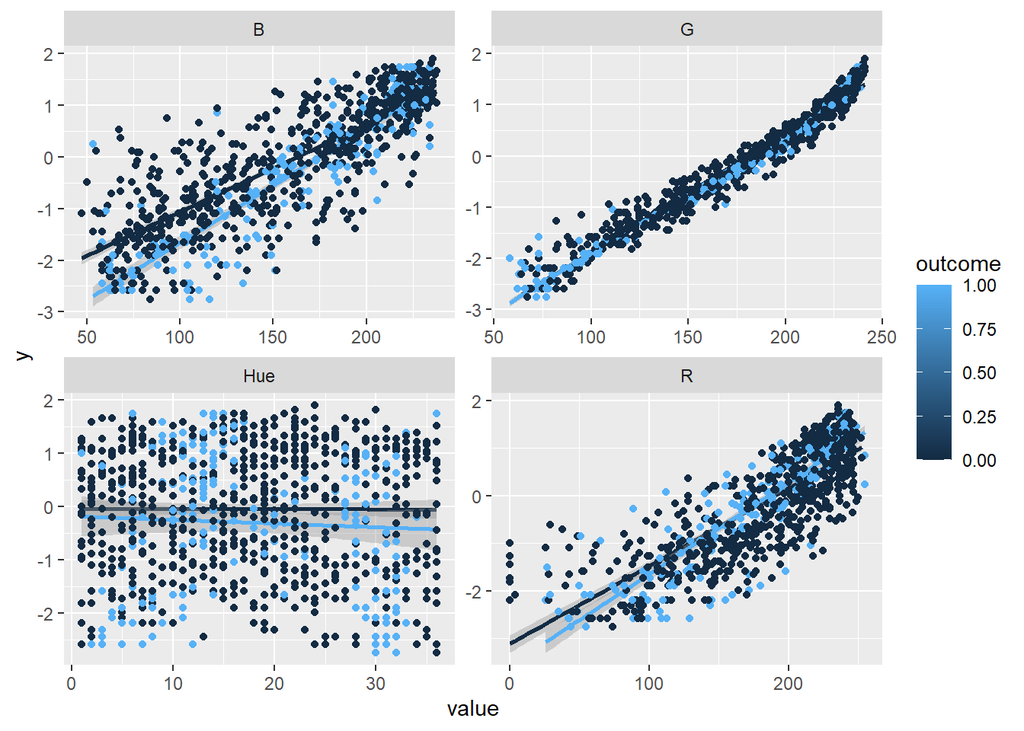

```r
dfii %>% tibble::rowid_to_column() %>% pivot_longer(c(R, G, B, Hue)) %>%
  ggplot(mapping = aes(x=value,y=y, color=outcome, group=outcome)) +
  geom_smooth(formula = 'y~x', method ='lm')+
  geom_point() + facet_wrap(~name, scales = 'free')
```

The plot between Hue and response variable is kind of linear and there’s no specific pattern associated with it.

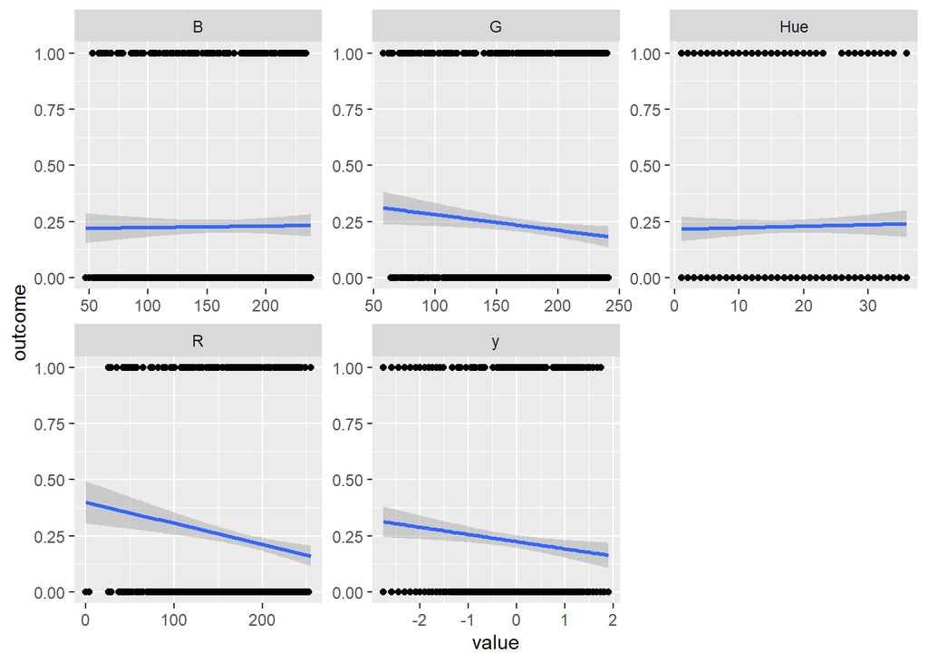

```r
#df %>% tibble::rowid_to_column() %>% pivot_longer(c(R, G, B))
lf %>% ggplot(mapping = aes(x=value,y=outcome)) +
  geom_smooth(formula = 'y~x', method ='glm')+
  geom_point() + facet_wrap(~name, scales = 'free')
```

This plot confirms the inference from the above scatter plot. The event and non-events are distributed similarly

#### Boxplot for the saturation faceted by the numerical columns corresponding to the outcome

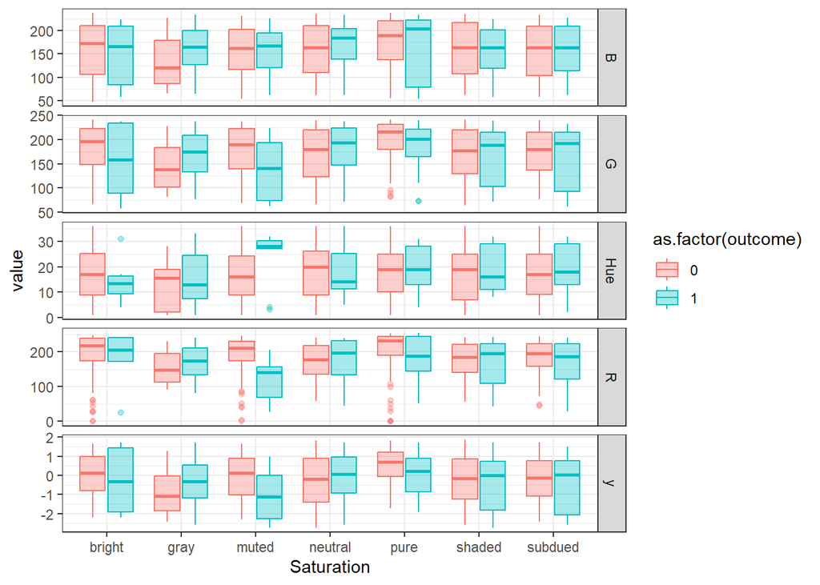

```r
lf %>% ggplot(mapping = aes(x = Saturation, y = value)) +
  geom_boxplot(mapping = aes(fill = as.factor(outcome), color = as.factor(outcome)), alpha = 0.35) +
  facet_grid(name ~ ., scales = "free_y") +
  theme_bw()
```

The average median across all the variations of saturation is similar, so we are not able to find any definitive direct relation between them with this approach. It’s also the same for response.

#### Boxplot for the Lightness faceted by the numerical columns corresponding to the outcome

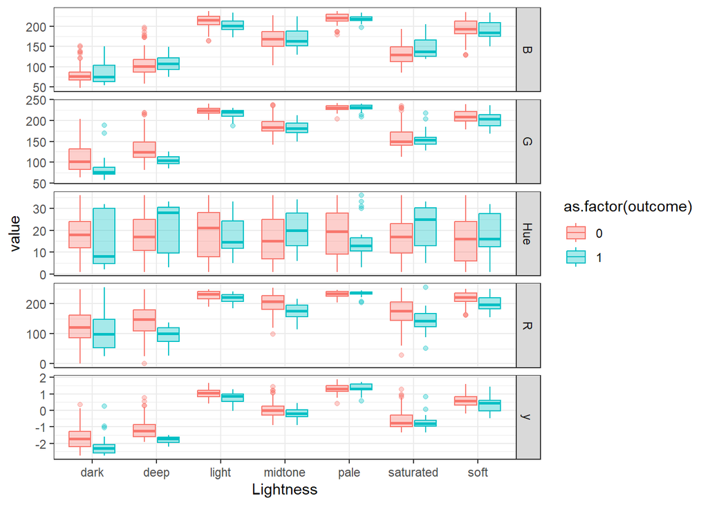

```r
lf %>% ggplot(mapping = aes(x = Lightness, y = value)) +
  geom_boxplot(mapping = aes(fill = as.factor(outcome), color = as.factor(outcome)), alpha = 0.35) +
  facet_grid(name ~ ., scales = "free_y") +
  theme_bw()
```

If we observe from the plot above, as the intensity of the color increases as per the lightness, the RBG values are getting smaller. The lighter versions have relatively larger values of RBG. We can say that the lightness does have correlation with RBG models.

The response variable seems skewed for mid-lighter versions of the colors. Darker colors are less preferred as per the plot above.

The relation ship between hue and lightness cannot be determined with this approach either.

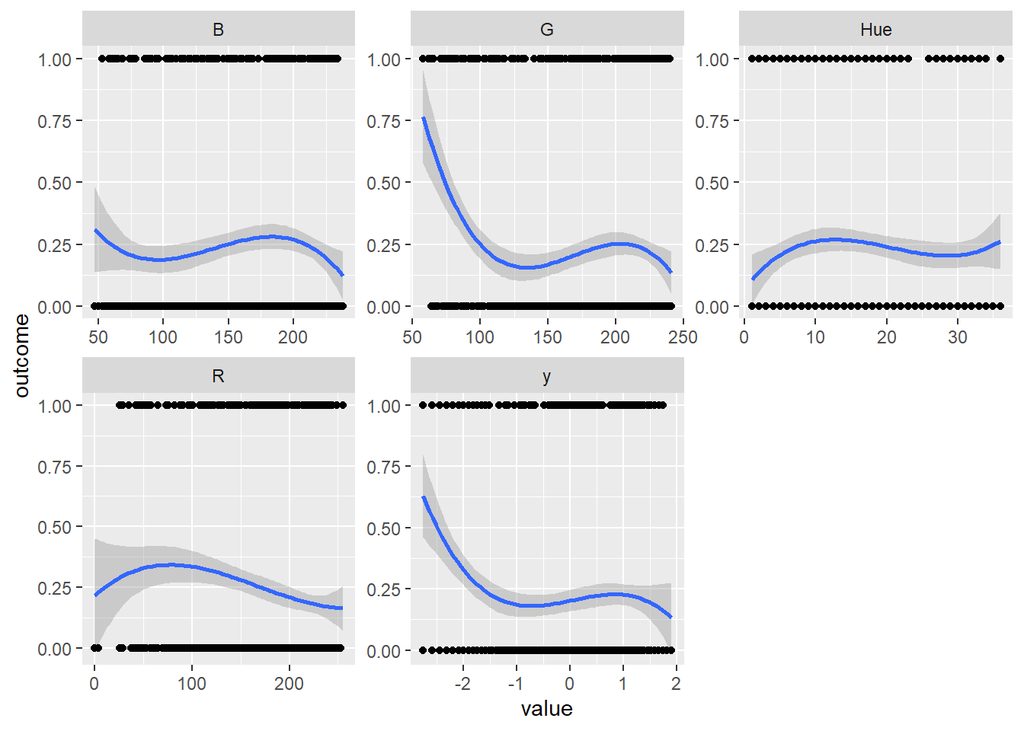

```r
lf %>% ggplot(mapping = aes(x=value,y=outcome)) +
  geom_smooth(formula = 'y~x*I(x^2)', method ='glm')+
  geom_point() + facet_wrap(~name, scales = 'free')
```

In this plot the relationship between Green and Outcome appears more consistent. The others are not as consistent as seen in the linear relationship plot.

#### Normality Diagonosis plot

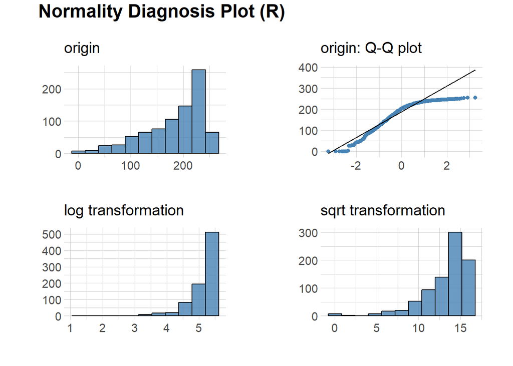

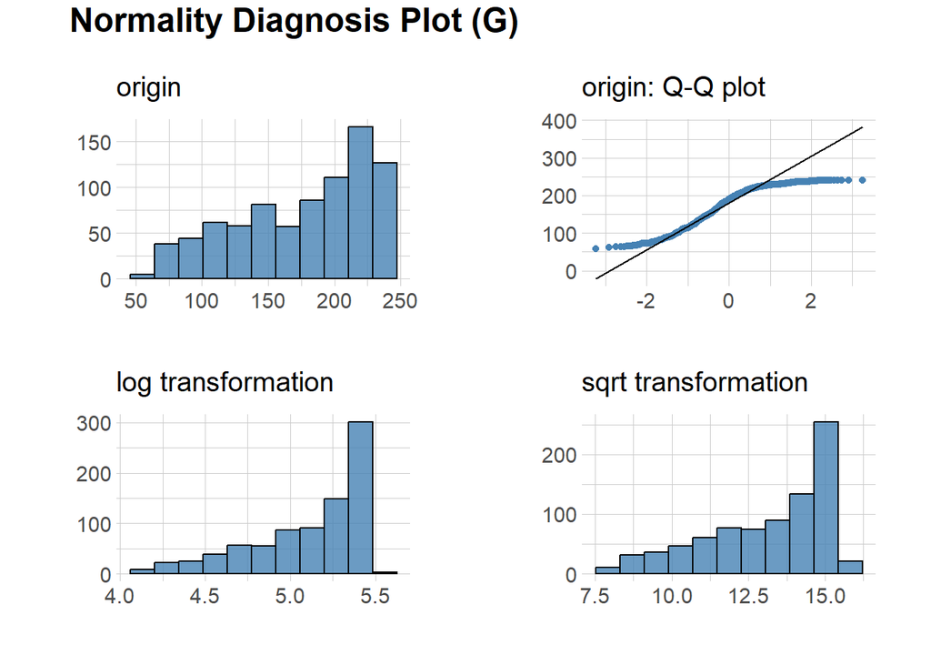

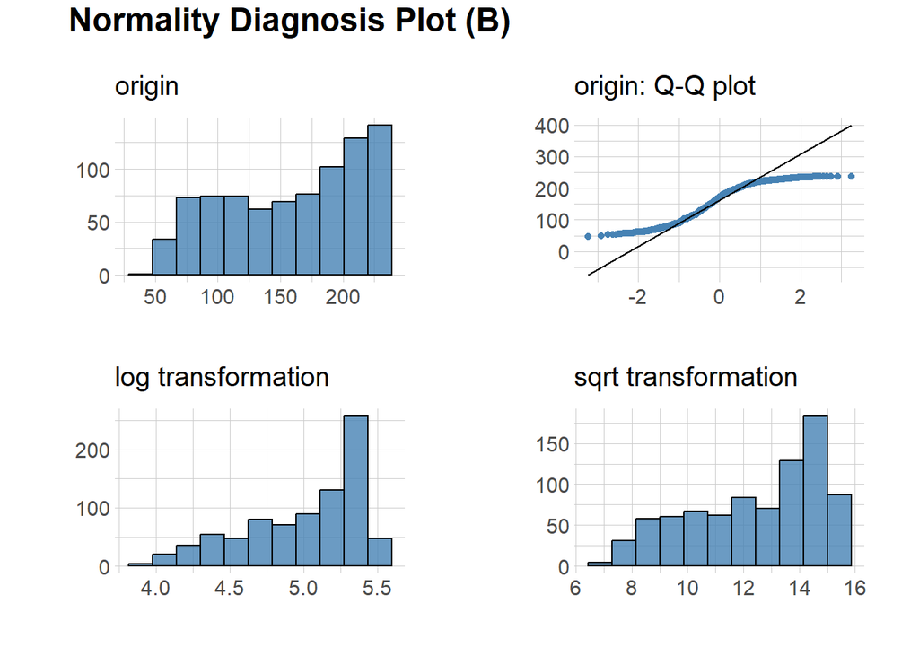

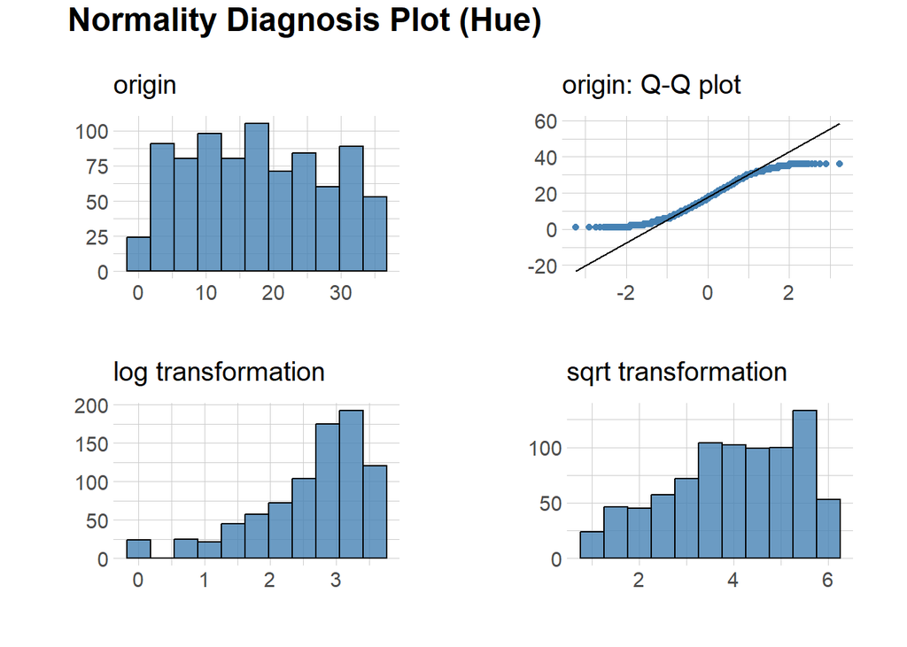

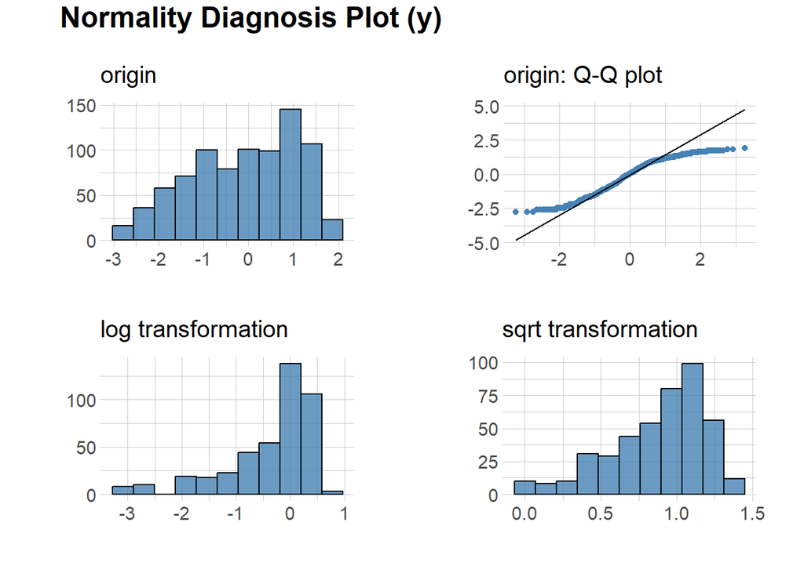

```r
num_col <- dfii %>% select(-outcome, -Lightness, -Saturation)
options(dlookr_offline=F)
dlookr::plot_normality(num_col)
```

If we observe the distribution of Q-Q plot for the RGB above, we can see that the variation for R, G, B values occurs below 100. The values for R are closer to the regression line but mostly below the line. The values for G is distributed around 50s and the values for B are distributed at around 100s. But as the values increases, the distribution is almost similar for all the three colors. This is obvious with the fact that as the intensity of one color increases, the shift corresponds to that color.

Apart from that the log and square root transformations were able to transform the data and helps identifying the skewness in the data.

#### Scatter plot to visualize the distribution of HSL model and response variable

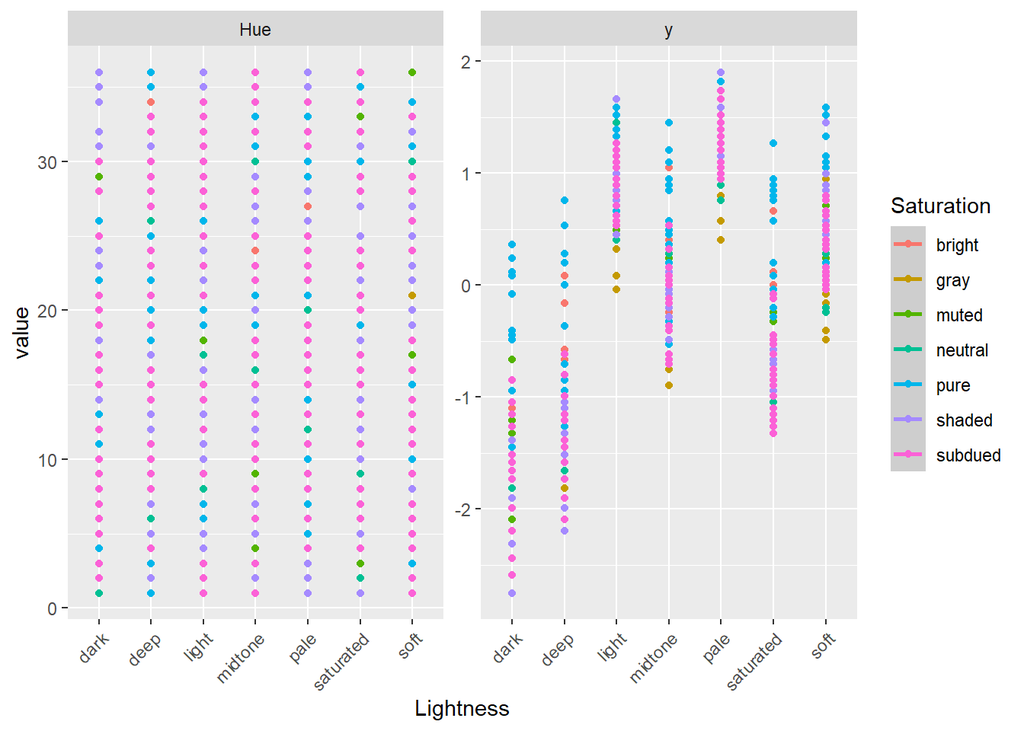

```r
dfii %>%
  tibble::rowid_to_column() %>%
  pivot_longer(cols = c( Hue, y)) %>%
  ggplot(mapping = aes(x = Lightness, y = value, color=Saturation )) +
  geom_smooth(formula = 'y~x', method = 'lm') +
  geom_point()+
  facet_wrap(~name, scales = 'free')+
   theme(axis.text.x = element_text(angle = 45, hjust = 1))
```

The above plot is plotted to observe the trends in the data. It’s clearly evident that individual color does not have impact on the outcome. The resultant mix of the three colors impacts the response.

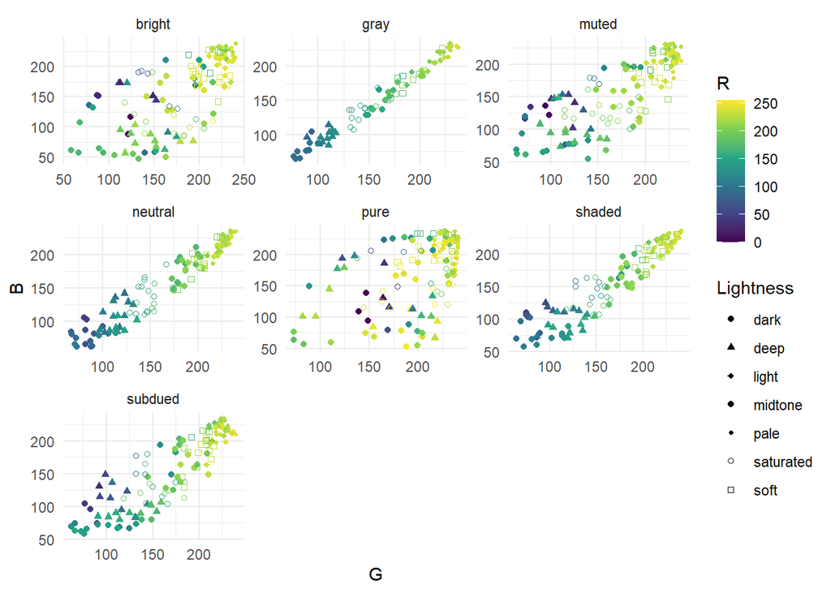

```r
dfii %>% tibble::rowid_to_column() %>%
  ggplot(mapping = aes(x=G, y=B, color=R, shape=Lightness)) + geom_point() +
  scale_color_viridis_c() +
  scale_shape_manual(values = c(16, 17, 18, 19, 20, 21, 22)) +
  facet_wrap(~Saturation, scales = 'free') + theme_minimal()
```

The above plot is based on the observation that the feature columns G and B effectively has more impact on the overall response. And as faceted based on the saturation, and scaled with features R, Lightness, we are able to effectively visualize the distribution of each feature based on their lightness type and Saturation.

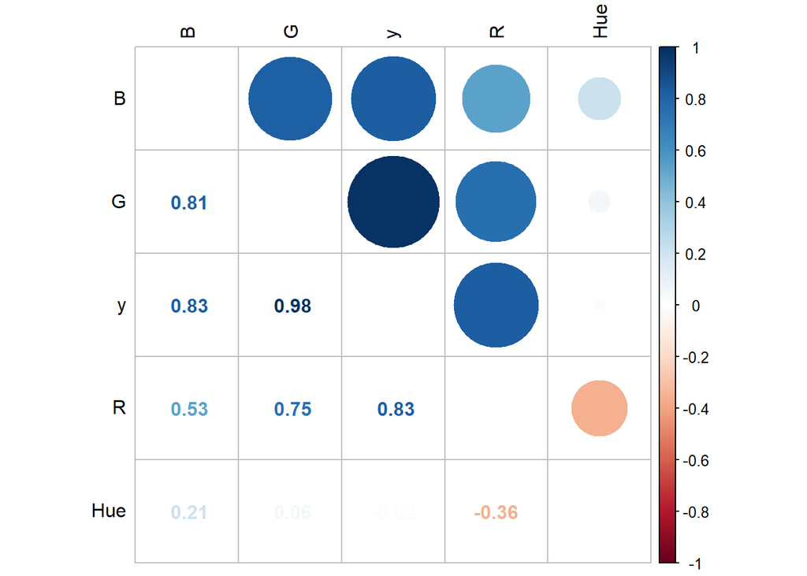

```r
dfii %>%
  select(R, G, B, Hue, y) %>%
  cor() %>%
  corrplot::corrplot.mixed(
    # method = 'color',
    order = 'AOE',
    tl.col = 'black',
    tl.pos = 'lt'
  )
```

```r
panel.cor <- function(x, y, digits = 2, prefix = "", cex.cor, ...) {
  usr <- par("usr")
  on.exit(par(usr))
  par(usr = c(0, 1, 0, 1))

  r <- cor(x, y)
  txt <- format(c(r, 0.123456789), digits = digits)[1]

  if (missing(cex.cor)) cex.cor <- 0.3/strwidth(txt)

  text(0.5, 0.5, paste0(prefix, txt), cex = cex.cor, col = "blue", font = 2)
}
```

#### Pairs plot corresponding to Lightness and Saturation

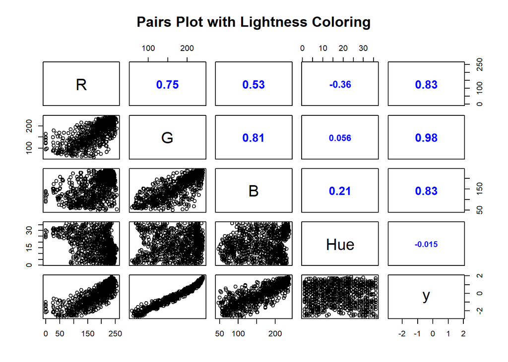

```r
suppressWarnings({
  dfii %>%
    select(-outcome, -Saturation, -Lightness) %>%
    pairs(
      # col = as.factor(dfii$Lightness),
      upper.panel = panel.cor,
      main = "Pairs Plot with Lightness Coloring"
    )
  # legend("right", legend = levels(as.factor(dfii$Lightness)), fill = palette())
})
```

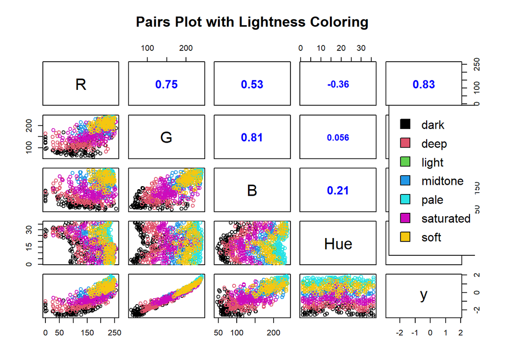

```r
suppressWarnings({
  dfii %>%
    select(-outcome, -Saturation, -Lightness) %>%
    pairs(
      col = as.factor(dfii$Lightness),
      upper.panel = panel.cor,
      main = "Pairs Plot with Lightness Coloring"
    )
  legend("right", legend = levels(as.factor(dfii$Lightness)), fill = palette())
})
```

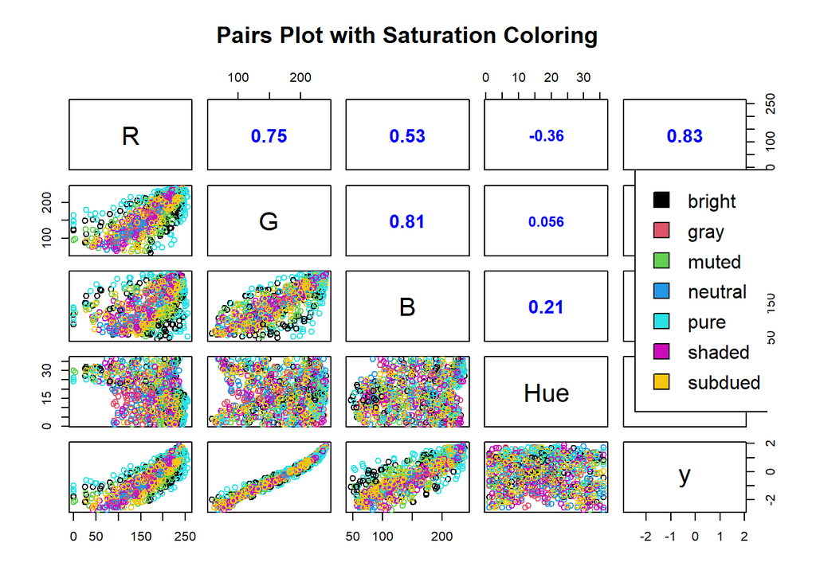

```r
suppressWarnings({
  dfii %>% select(-outcome, -Saturation, -Lightness) %>%
    pairs( col = as.factor(dfii$Saturation),
      upper.panel = panel.cor,
      main = "Pairs Plot with Saturation Coloring")

  # Add color legend
  legend("right", legend = levels(as.factor(dfii$Saturation)), fill = palette())
})
```

If we see the aqua marine color rings of pure saturation, it can be observed that for the R,G,B colors, it seems to be like a U curve on top of all the other levels of saturation. If we go by the ordinal order of the saturation levels, we can peel of each level from the stack except for Hue.

** PCA analysis **

```r
df_features <- dfii %>% select(-y, -outcome, -Lightness, -Saturation)
df_pca <- prcomp(df_features, center = T, scale.=T)
df_pca %>% glimpse()
```

```
## List of 5
##  $ sdev    : num [1:4] 1.552 1.108 0.502 0.335
##  $ rotation: num [1:4, 1:4] 0.551 0.6174 0.5606 -0.0316 -0.3625 ...
##   ..- attr(*, "dimnames")=List of 2
##   .. ..$ : chr [1:4] "R" "G" "B" "Hue"
##   .. ..$ : chr [1:4] "PC1" "PC2" "PC3" "PC4"
##  $ center  : Named num [1:4] 183.3 176.3 160.3 17.7
##   ..- attr(*, "names")= chr [1:4] "R" "G" "B" "Hue"
##  $ scale   : Named num [1:4] 57.3 50.1 54.6 10.1
##   ..- attr(*, "names")= chr [1:4] "R" "G" "B" "Hue"
##  $ x       : num [1:835, 1:4] -2.53 -2.74 -2.14 -2.72 -2.5 ...
##   ..- attr(*, "dimnames")=List of 2
##   .. ..$ : NULL
##   .. ..$ : chr [1:4] "PC1" "PC2" "PC3" "PC4"
##  - attr(*, "class")= chr "prcomp"
```

```r
df_pca$x %>% dim()
```

```
## [1] 835   4
```

```r
df_pca$x %>% colnames()
```

```
## [1] "PC1" "PC2" "PC3" "PC4"
```

#### Box plot of the summary statistics for the interaction between PCs and Saturation/Lightness, Pcs gouped by the levels of Saturation, Lightness.

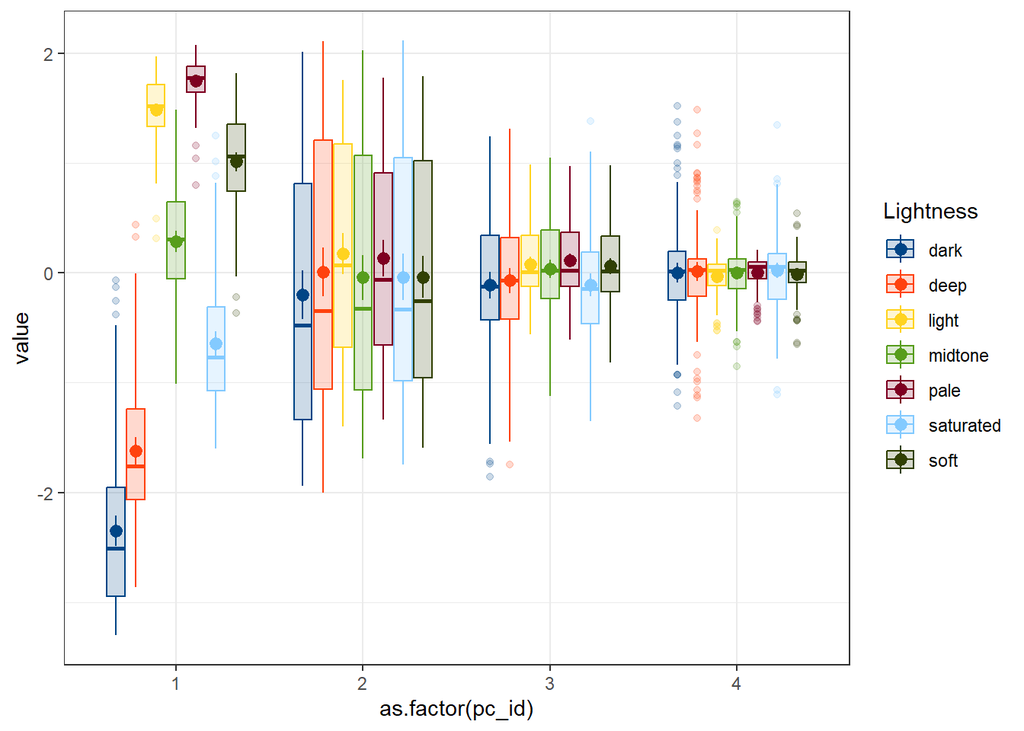

```r
df_pca$x %>% as.data.frame() %>% tibble::as_tibble() %>%
  tibble::rowid_to_column() %>%
  bind_cols(dfii %>% select(Lightness)) %>%
  pivot_longer(!c("rowid", "Lightness")) %>%
  mutate(pc_id = as.numeric(stringr::str_extract(name, "\\d+"))) %>%
  ggplot(mapping = aes(x = as.factor(pc_id), y = value)) +
  geom_boxplot(mapping = aes(fill = Lightness, color = Lightness,
                             group = interaction(pc_id, Lightness)),
               alpha = 0.2) +
  stat_summary(fun.data = "mean_se",
               mapping = aes(group = interaction(pc_id, Lightness),
                             color = Lightness),
               fun.args = list(mult = 2),
               position = position_dodge(0.75)) +
  ggthemes::scale_color_calc() +
  ggthemes::scale_fill_calc() +
  theme_bw()
```

This indicates that, the classification model fits well to train on the data based on the lightness levels.

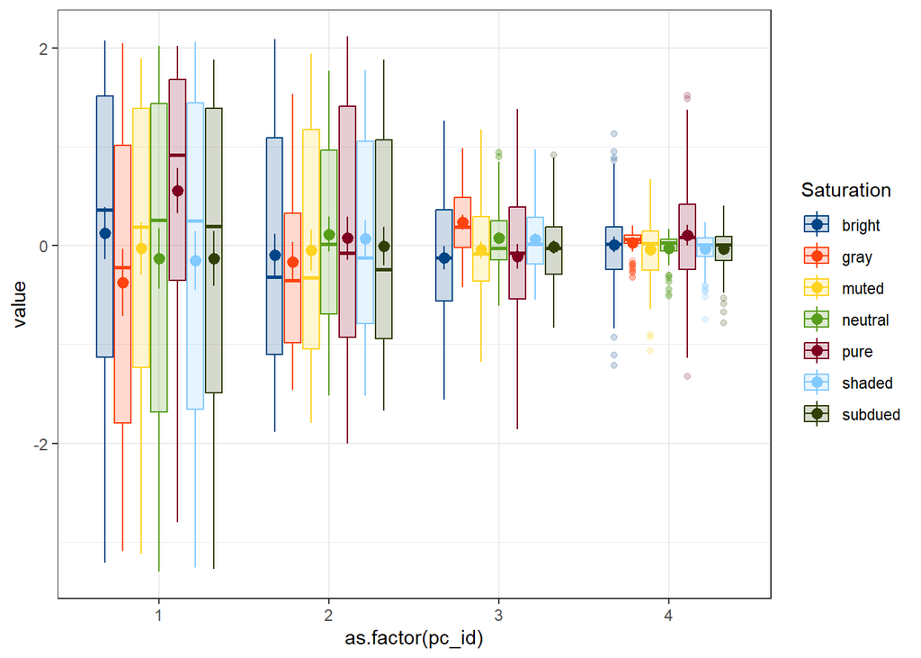

```r
df_pca$x %>% as.data.frame() %>% tibble::as_tibble() %>%
  tibble::rowid_to_column() %>%
  bind_cols(dfii %>% select(Saturation)) %>%
  pivot_longer(!c("rowid", "Saturation")) %>%
  mutate(pc_id = as.numeric(stringr::str_extract(name, "\\d+"))) %>%
  ggplot(mapping = aes(x = as.factor(pc_id), y = value)) +
  geom_boxplot(mapping = aes(fill = Saturation, color = Saturation,
                             group = interaction(pc_id, Saturation)),
               alpha = 0.2) +
  stat_summary(fun.data = "mean_se",
               mapping = aes(group = interaction(pc_id, Saturation),
                             color = Saturation),
               fun.args = list(mult = 2),
               position = position_dodge(0.75)) +
  ggthemes::scale_color_calc() +
  ggthemes::scale_fill_calc() +
  theme_bw()
```

The above plot shows the box plot of PC components summary statistics grouped by the levels of saturation. As can be seen there is no distinct separation between the median levels per PC component against the levels of saturation as there is more overlapping.

#### Box plot of the summary statistics for the interaction between PCs and outcome

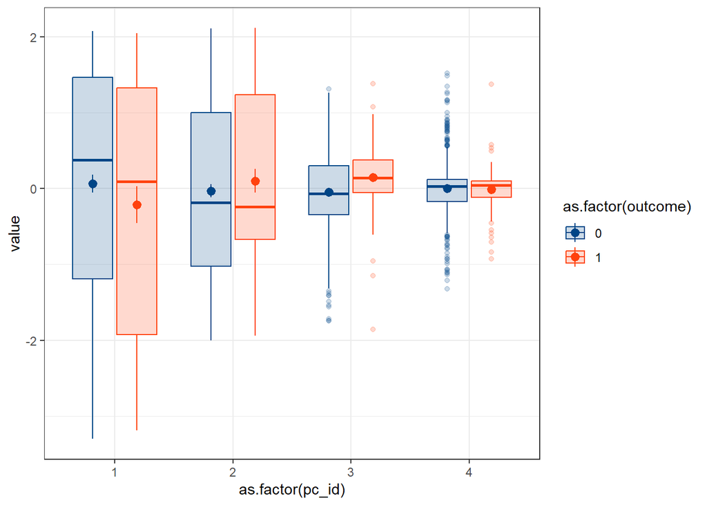

```r
df_pca$x %>% as.data.frame() %>% tibble::as_tibble() %>%
  tibble::rowid_to_column() %>%
  bind_cols(dfii %>% select(outcome)) %>%
  pivot_longer(!c("rowid", "outcome")) %>%
  mutate(pc_id = as.numeric(stringr::str_extract(name, "\\d+"))) %>%
  ggplot(mapping = aes(x = as.factor(pc_id), y = value)) +
  geom_boxplot(mapping = aes(fill = as.factor(outcome), color = as.factor(outcome),
                             group = interaction(pc_id, outcome)),
               alpha = 0.2) +
  stat_summary(fun.data = "mean_se",
               mapping = aes(group = interaction(pc_id, outcome),
                             color = as.factor(outcome)),
               fun.args = list(mult = 2),
               position = position_dodge(0.75)) +
  ggthemes::scale_color_calc() +
  ggthemes::scale_fill_calc() +
  theme_bw()
```

#### Contribution plot of each component

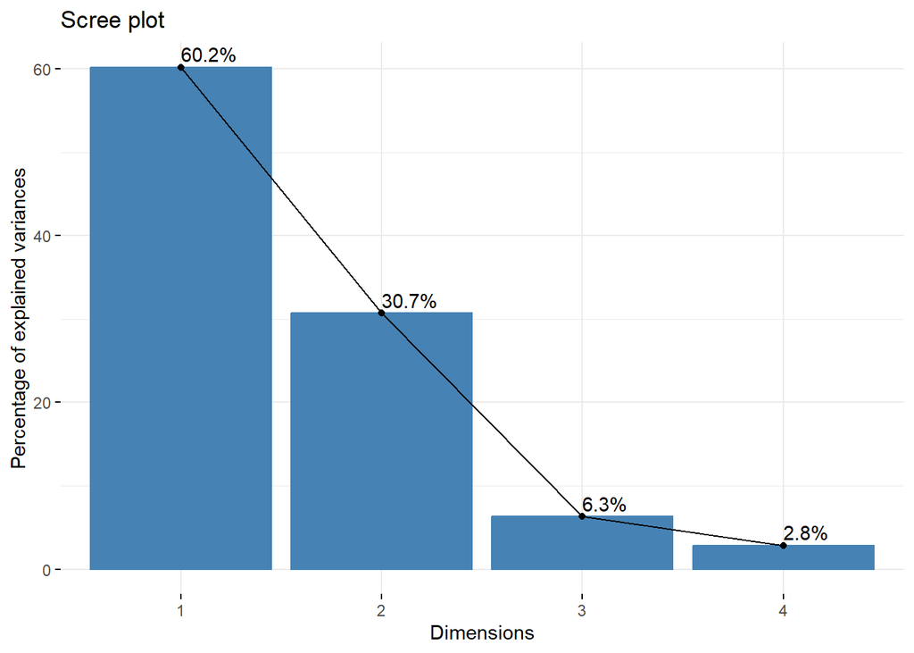

```r
factoextra::fviz_screeplot(df_pca, ncp=16, addlabels=T)
```

The above plot shows the contribution of each PC and how much proportion of the data is it efficiently capturing.

#### Variable factor Graph

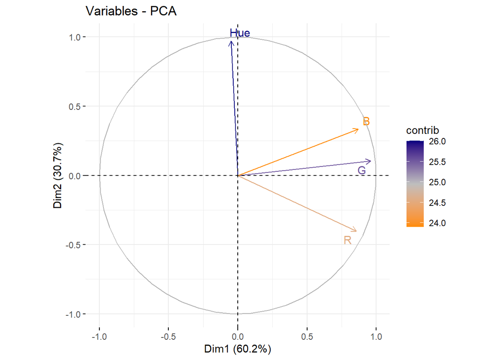

```r
factoextra::fviz_pca_var(df_pca, col.var='contrib',labs='',
                         gradient.cols = c("darkorange", "grey", 'navyblue'),
                         repel = TRUE)
```

The color scale indicates the association between the PCs and variables.

#### Contribution plot of variables

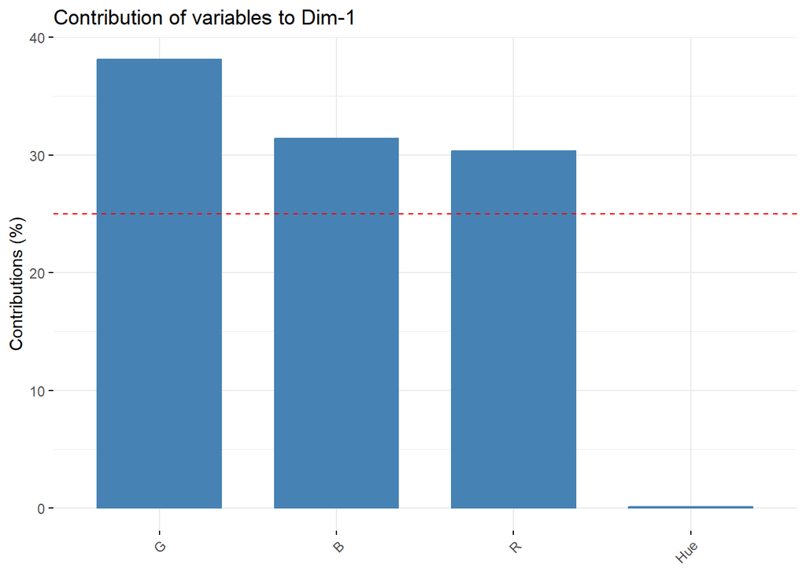

```r
factoextra::fviz_contrib(df_pca, choice='var', axes=1)
```

The plot above shows the contribution of each variable. The dashed line in the middle is the uniform contribution line which acts as a threshold. The more the lenght of the bar beyond the dashed line the more the contribution and in this case, `R,G,B` seems to have higher contributions respectively compared to the `Hue` variable.